# Logistic regression

Susanna Jernberg

# Logistic regression

### Overview of the data

This data is a joined data of studen achievment data in a secondary school. “The data attributes include student grades, demographic, social and school related features) and it was collected by using school reports and questionnairesThe variables not used for joining the two data have been combined by averaging (including the grade variables”. I have added column’alc_use’ which is the average of ‘Dalc’ and ‘Walc’, and the column ‘high_use’ whcih is TRUE if ‘alc_use’ is higher than 2 and FALSE otherwise.

```r
alc<-read.csv(file="D:/Users/E1002220/Opinnot/Data science/IODS-project/data/alc_data.csv", sep="\t")
library(dplyr)
glimpse(alc)
```

```
## Observations: 382
## Variables: 35
## $ school     <fct> GP, GP, GP, GP, GP, GP, GP, GP, GP, GP, GP, GP, GP,...
## $ sex        <fct> F, F, F, F, F, M, M, F, M, M, F, F, M, M, M, F, F, ...
## $ age        <int> 18, 17, 15, 15, 16, 16, 16, 17, 15, 15, 15, 15, 15,...
## $ address    <fct> U, U, U, U, U, U, U, U, U, U, U, U, U, U, U, U, U, ...
## $ famsize    <fct> GT3, GT3, LE3, GT3, GT3, LE3, LE3, GT3, LE3, GT3, G...
## $ Pstatus    <fct> A, T, T, T, T, T, T, A, A, T, T, T, T, T, A, T, T, ...
## $ Medu       <int> 4, 1, 1, 4, 3, 4, 2, 4, 3, 3, 4, 2, 4, 4, 2, 4, 4, ...
## $ Fedu       <int> 4, 1, 1, 2, 3, 3, 2, 4, 2, 4, 4, 1, 4, 3, 2, 4, 4, ...
## $ Mjob       <fct> at_home, at_home, at_home, health, other, services,...
## $ Fjob       <fct> teacher, other, other, services, other, other, othe...
## $ reason     <fct> course, course, other, home, home, reputation, home...
## $ nursery    <fct> yes, no, yes, yes, yes, yes, yes, yes, yes, yes, ye...
## $ internet   <fct> no, yes, yes, yes, no, yes, yes, no, yes, yes, yes,...
```

[output cut: 22 more lines]

Based on the summaries above, I have chosen 4 variables to explain the alcohol use: absences, grades, activities and sex. Absences from school might correlate with the alcohol use by increasing it the more there are absences, whereas the etra-curricular actitivities may decrease it because the student has other things to do. The better grades, the less alcohol the student might be drinking because to achieve good grades, one need to study and has not that much time to drink. And sex was chosen because it is known from previous studies, that boys usually consume more alcohol than girls.

Here are bar plots of each variable and summary statistics by group

```r
library(tidyr)
```

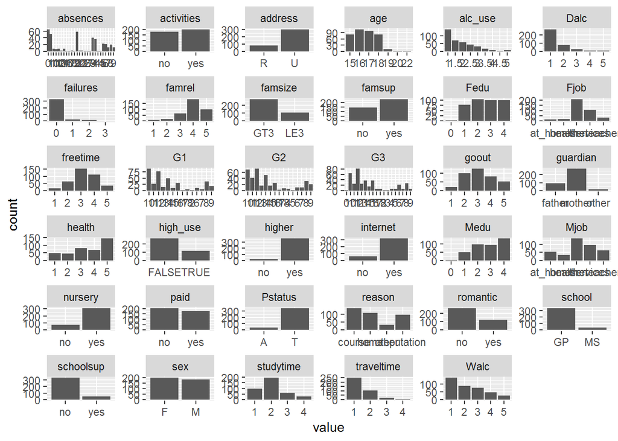

```r
library(ggplot2)
gather(alc) %>%ggplot(aes(value), col=sex)+facet_wrap("key", scales="free")+geom_bar()
```

```r
alc%>% group_by(sex, high_use)%>% summarise(count = n(), mean_grade=mean(G3))
```

```
## # A tibble: 4 x 4
## # Groups:   sex [?]
##   sex   high_use count mean_grade
##   <fct> <lgl>    <int>      <dbl>
## 1 F     FALSE      156       11.4
## 2 F     TRUE        42       11.7
## 3 M     FALSE      112       12.2
## 4 M     TRUE        72       10.3
```

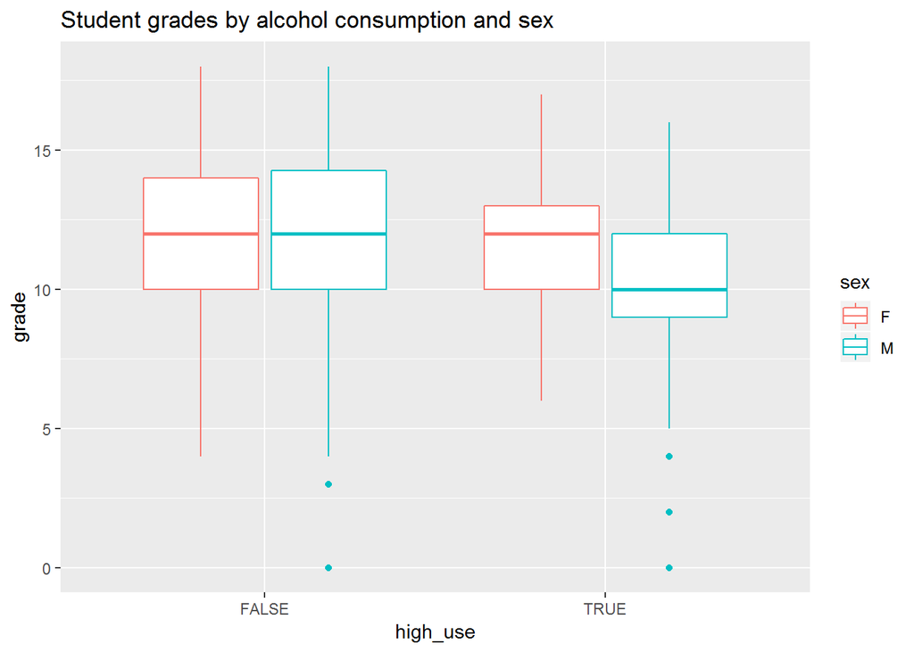

```r
par(mfrow=c(2,2))

g1<-ggplot(alc, aes(x=high_use, y=G3, col=sex))
g1 + geom_boxplot() + ylab("grade")+ggtitle("Student grades by alcohol consumption and sex")
```

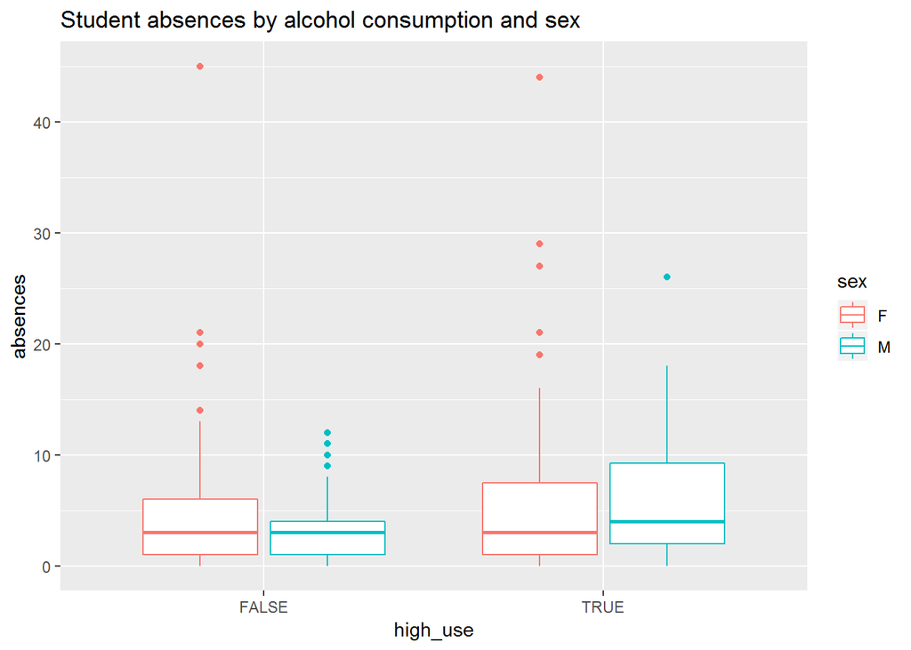

```r
g2<-ggplot(alc, aes(x=high_use, y=absences, col=sex))
g2 + geom_boxplot() + ylab("absences")+ggtitle("Student absences by alcohol consumption and sex")
```

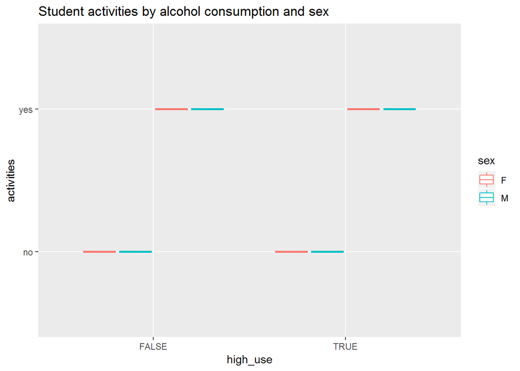

```r
g3<-ggplot(alc, aes(x=high_use, y=activities, col=sex))
g3 + geom_boxplot() + ylab("activities")+ggtitle("Student activities by alcohol consumption and sex")
```

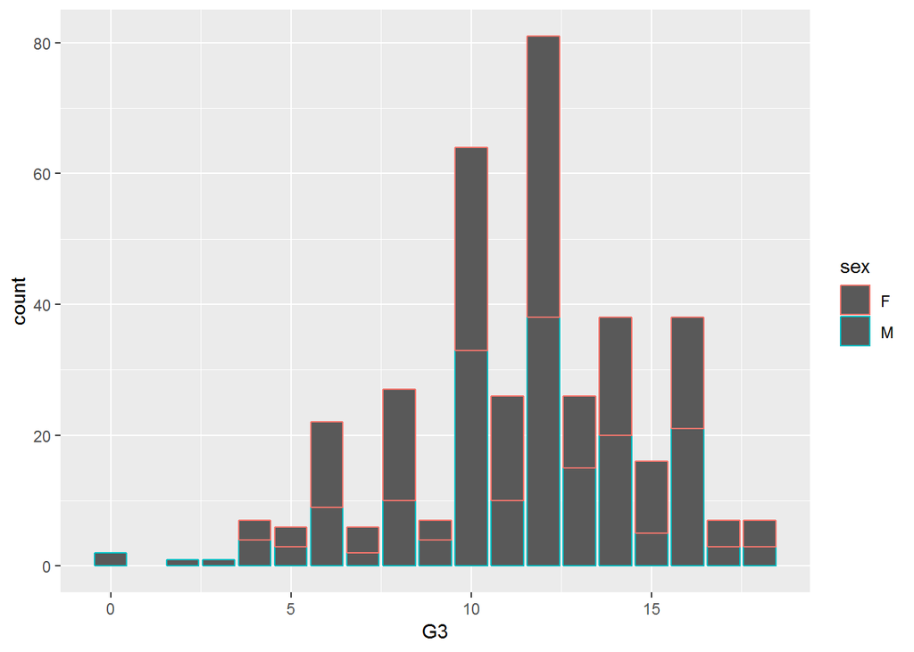

```r
g1<-ggplot(alc, aes(x=G3, col=sex))
g1 + geom_bar()
```

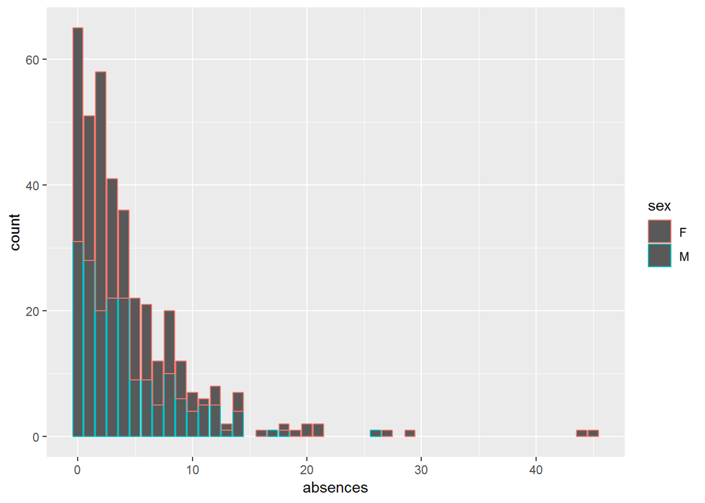

```r
g2<-ggplot(alc, aes(x=absences, col=sex))
g2 + geom_bar()
```

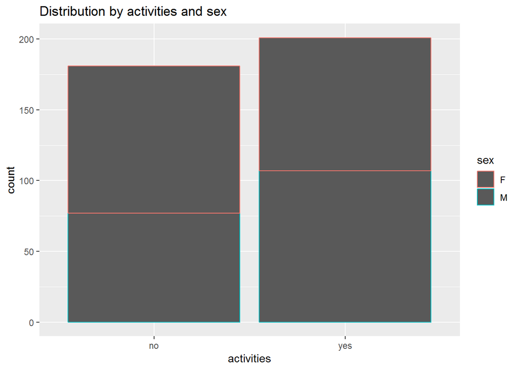

```r
g3<-ggplot(alc, aes(x=activities, col=sex))
g3 + geom_bar() +ggtitle("Distribution by activities and sex")
```

### Here I have fit the model with chosen variables and show the summary

```r
model<-glm(high_use ~ absences + activities + sex + G3, data=alc, family="binomial")
summary(model)
```

```
##
## Call:
## glm(formula = high_use ~ absences + activities + sex + G3, family = "binomial",
##     data = alc)
##
## Deviance Residuals:
##     Min       1Q   Median       3Q      Max
## -2.3147  -0.8418  -0.6202   1.0719   2.2345
##
## Coefficients:
##               Estimate Std. Error z value Pr(>|z|)
## (Intercept)   -0.86787    0.46586  -1.863   0.0625 .
## absences       0.09300    0.02298   4.047 5.19e-05 ***
## activitiesyes -0.33715    0.24034  -1.403   0.1607
## sexM           1.02244    0.24410   4.189 2.81e-05 ***
## G3            -0.07091    0.03601  -1.969   0.0489 *
## ---
## Signif. codes:  0 '***' 0.001 '**' 0.01 '*' 0.05 '.' 0.1 ' ' 1
##
## (Dispersion parameter for binomial family taken to be 1)
##
##     Null deviance: 465.68  on 381  degrees of freedom
## Residual deviance: 423.53  on 377  degrees of freedom
## AIC: 433.53
##
## Number of Fisher Scoring iterations: 4
```

```r
coef(model)
```

```
##   (Intercept)      absences activitiesyes          sexM            G3
##   -0.86786569    0.09299535   -0.33714643    1.02243885   -0.07090829
```